# TIGPS2023手足問卷成果報告

### 對校態度_讀書風氣興盛 (樣本數=623)

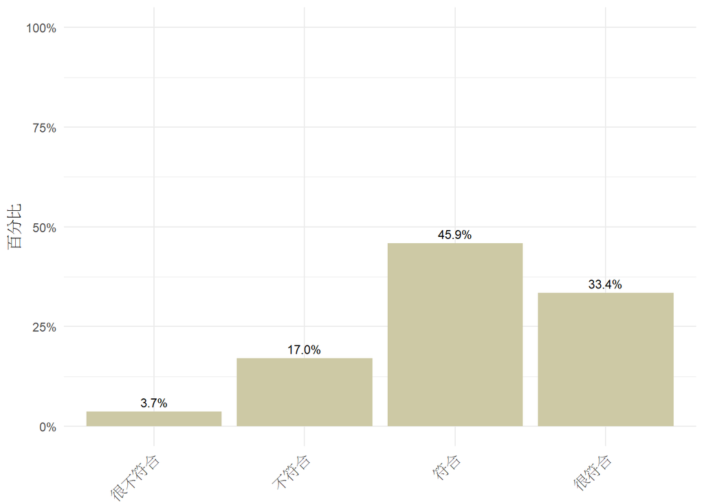

### 對校態度_重視學生意見 (樣本數=623)

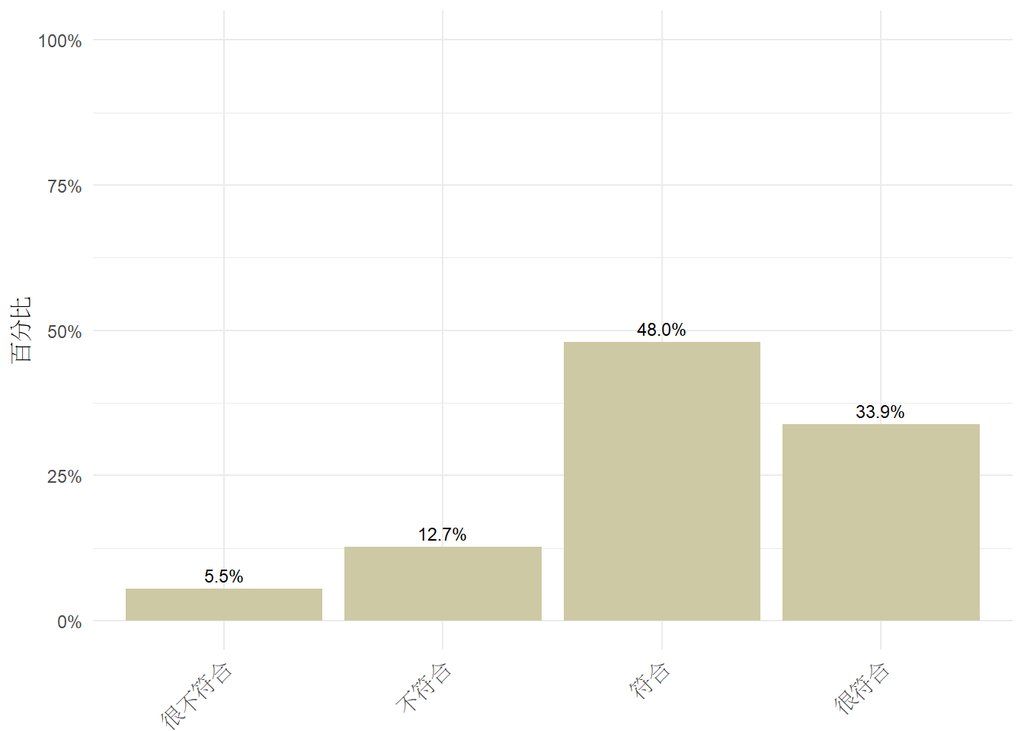

### 對校態度_學生逃學或翹課情況嚴重 (樣本數=623)

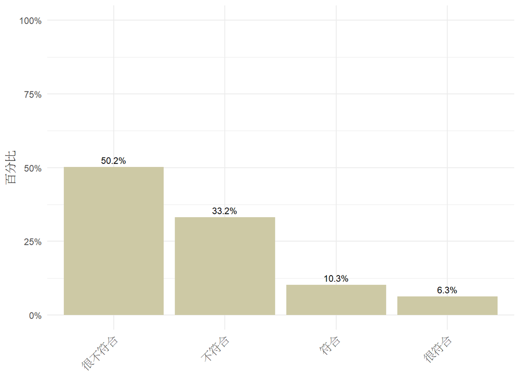

### 對校態度_學生抽菸或喝酒問題嚴重 (樣本數=623)

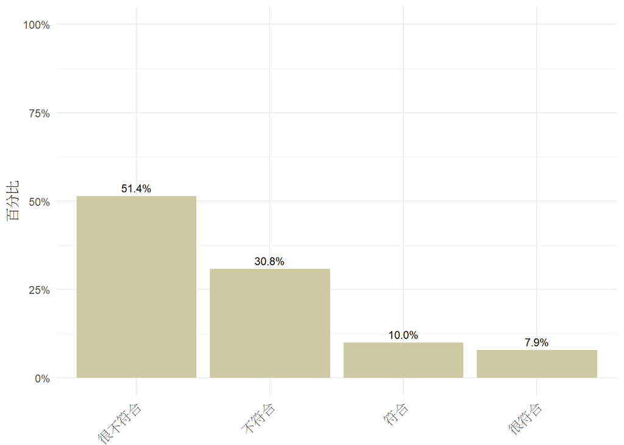

### 對校態度_校長、訓導人員或職員不關心學生 (樣本數=623)

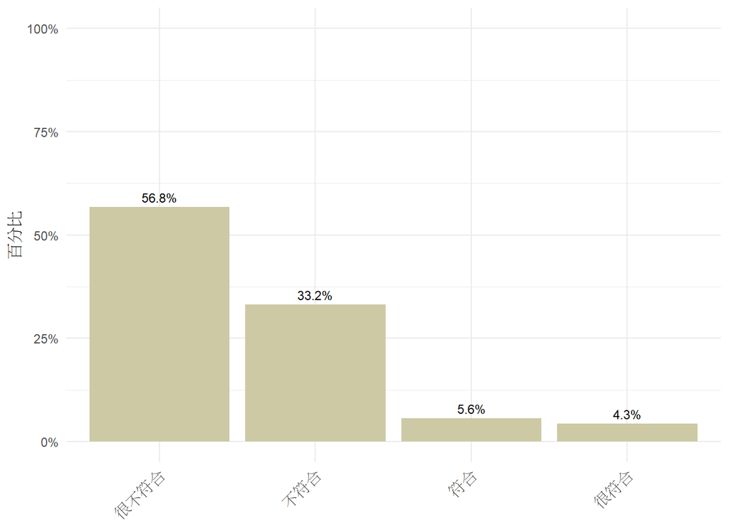

### 對校認同_我喜歡學校 (樣本數=623)

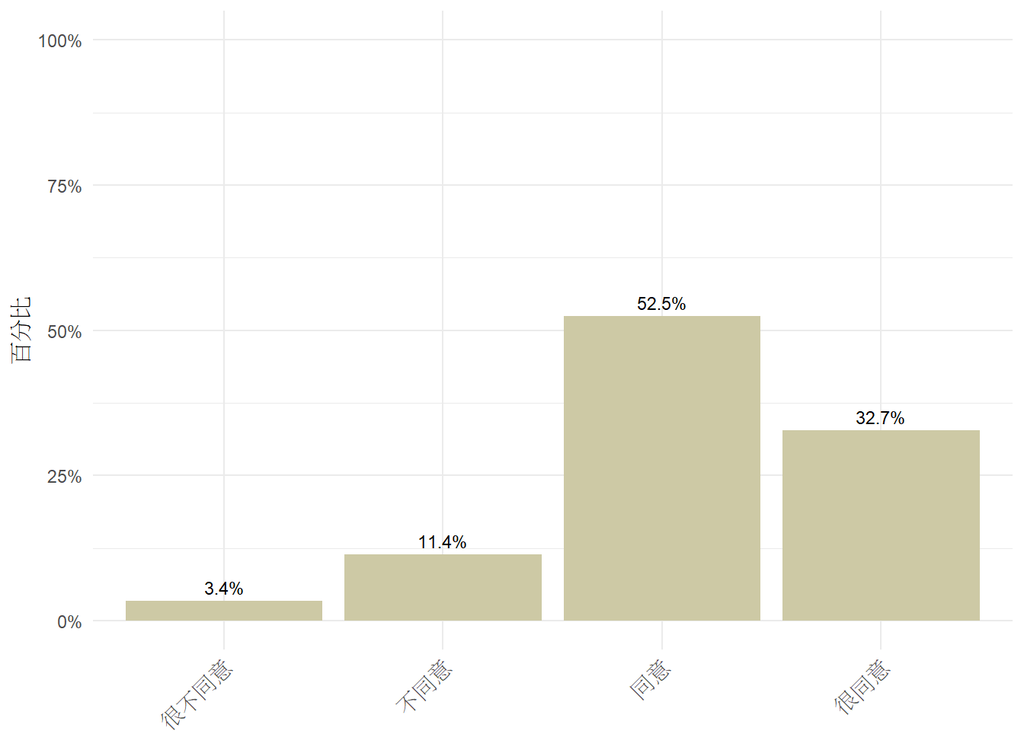

### 對校認同_我不認為我是學校的一份子 (樣本數=623)

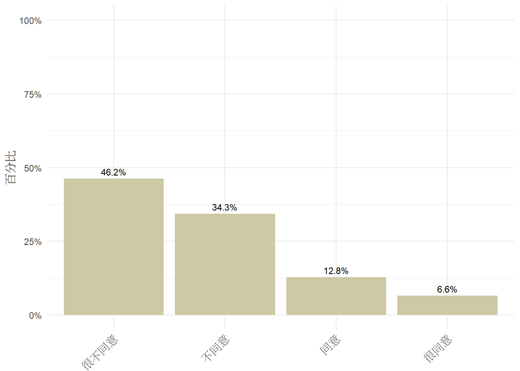

### 對校認同_我以我的學校為榮 (樣本數=623)

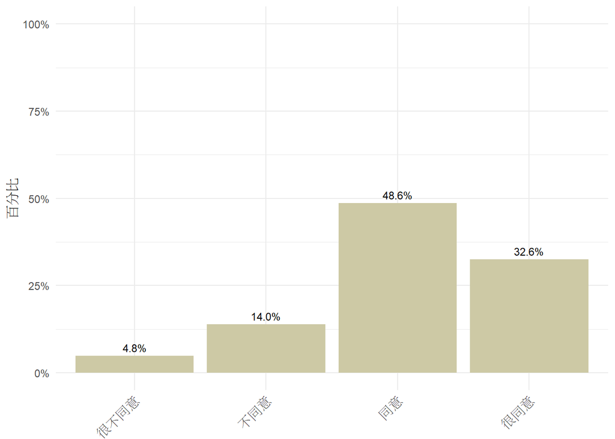

### 班級凝聚力_當我需要他們的時候，我的同學們總是會適時伸出援手 (樣本數=615)

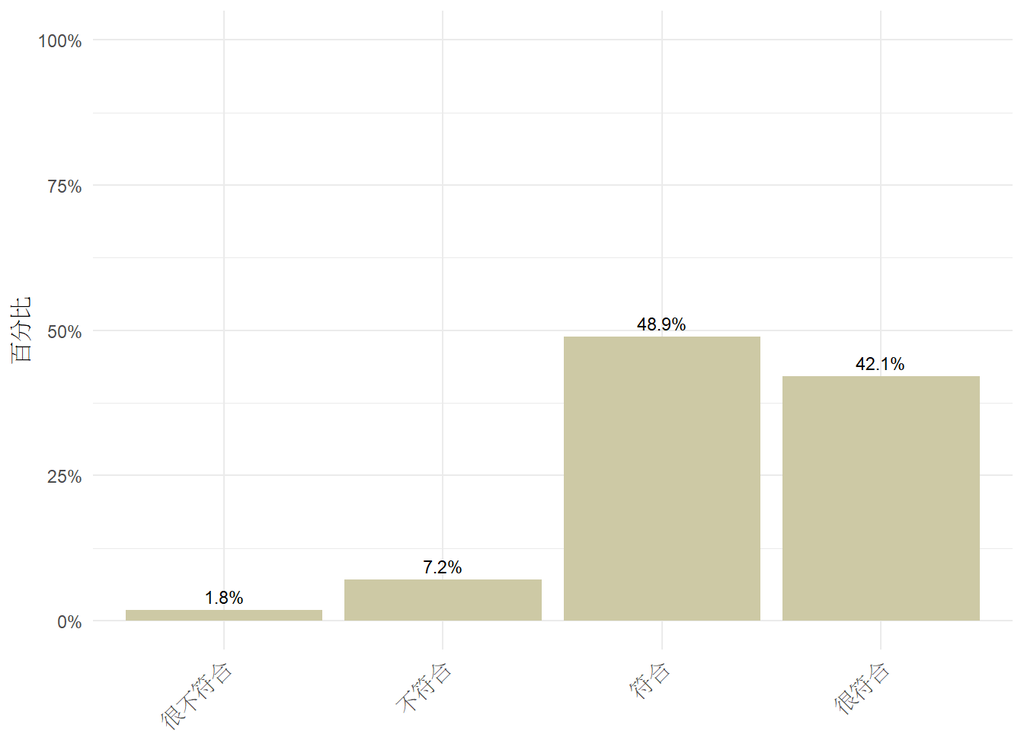

### 班級凝聚力_我不喜歡與班上同學來往 (樣本數=615)

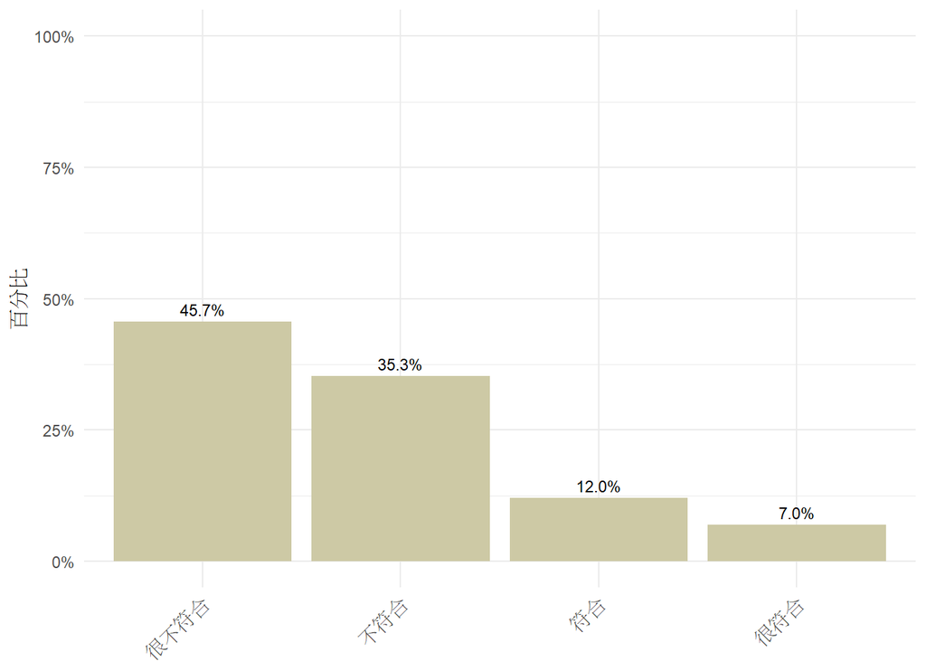

### 班級凝聚力_當班上的同學需要我的時候，我總是會適時伸出援手 (樣本數=615)

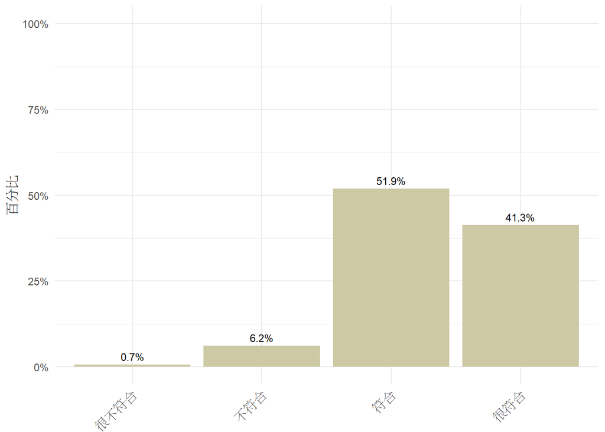

### 班級凝聚力_我們班的同學相親相愛，猶如一家人 (樣本數=615)

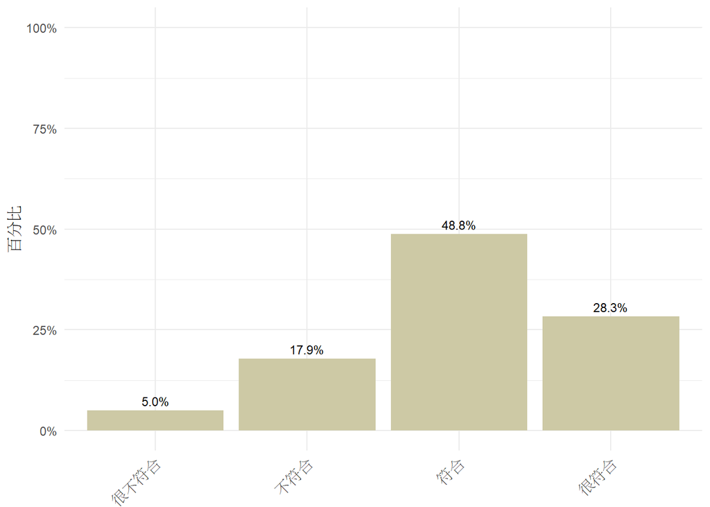

### 班級凝聚力_與其他班級比較，我們班的同學彼此之間，最互相信賴 (樣本數=615)

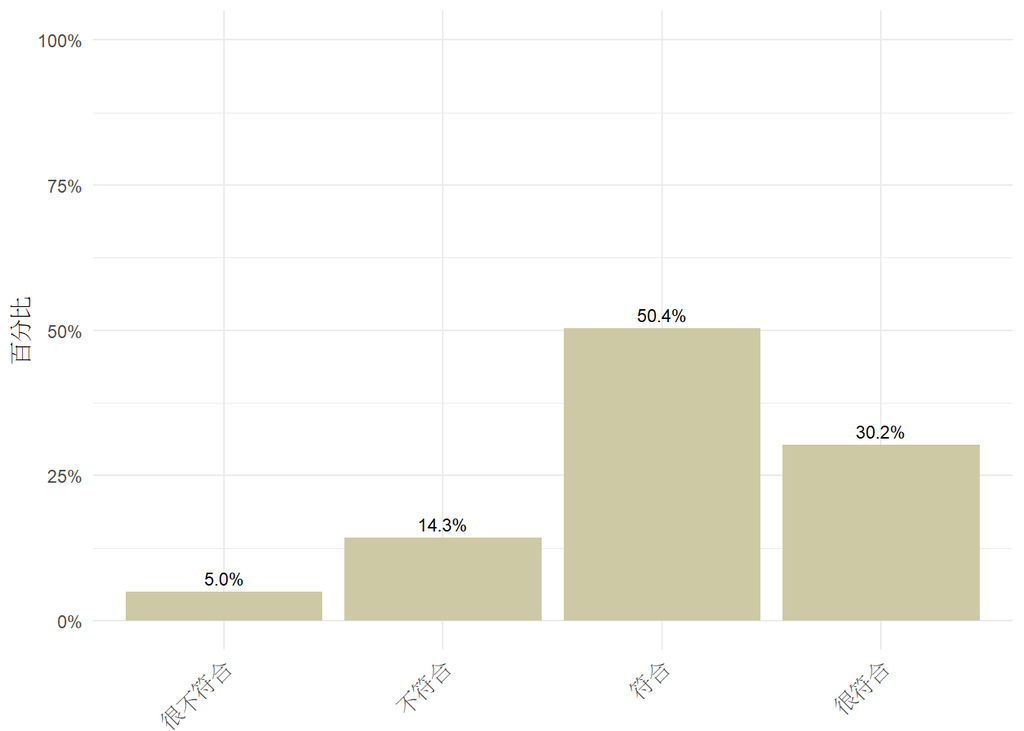

### 課業進度 (樣本數=617)

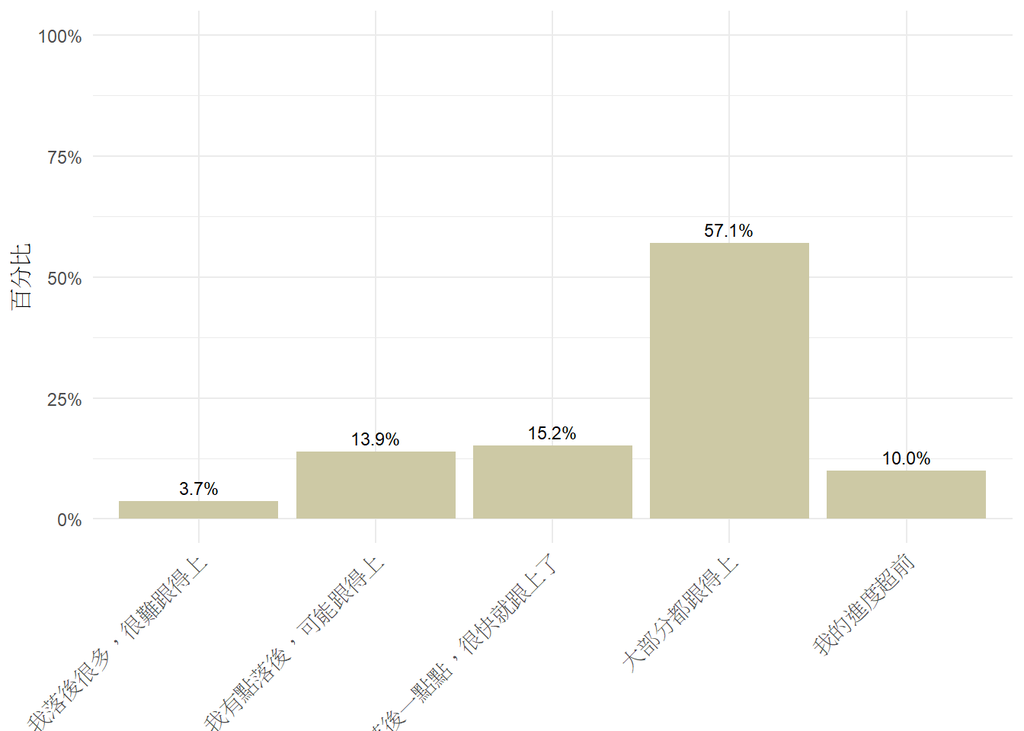

### 成績排名 (樣本數=562)

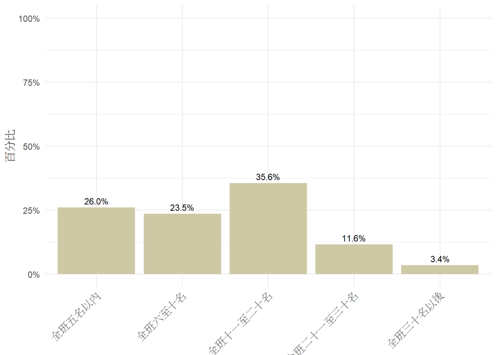

### 父母學業要求 (樣本數=597)

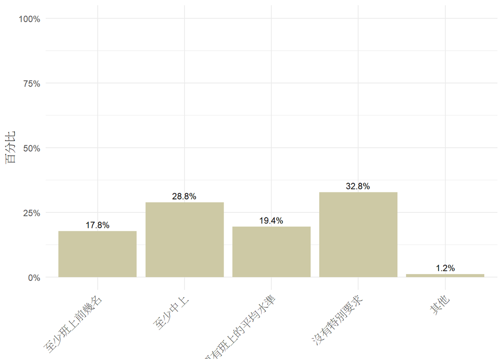

### 學習管理能力_讀書或寫作業時，我會先將無關的網站、即時通訊、手機APP或提醒聲音關掉 (樣本數=610)

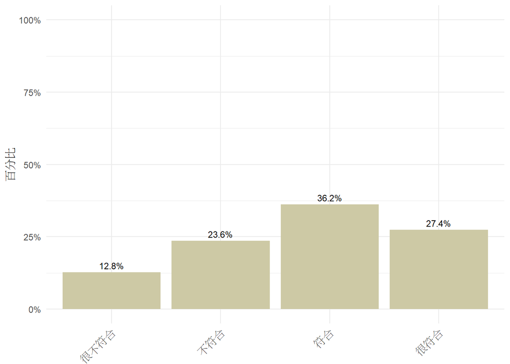

### 學習管理能力_我能要求自己先完成作業或讀書進度後，才能去看我喜歡的網站或玩手機 (樣本數=610)

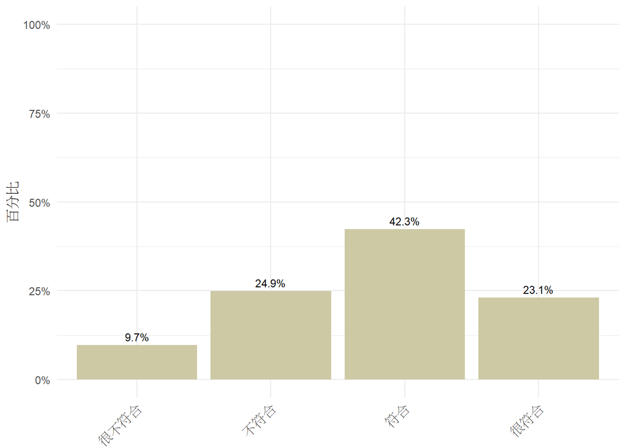

### 學習管理能力_我會運用學習平台上的儀表板，了解自己的認真或表現情況（如：目前得分、作業缺交、影片觀看記錄、相對於全班的表現等） (樣本數=610)

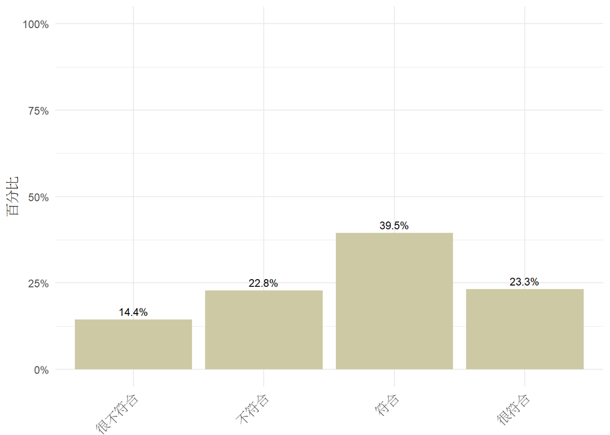

### 學習管理能力_我會運用學習平台以外的軟體安排我的學習進度（如：安排時間-Google日曆、專注-Forrest、備忘錄-Notion、閃字卡-Anki等） (樣本數=610)

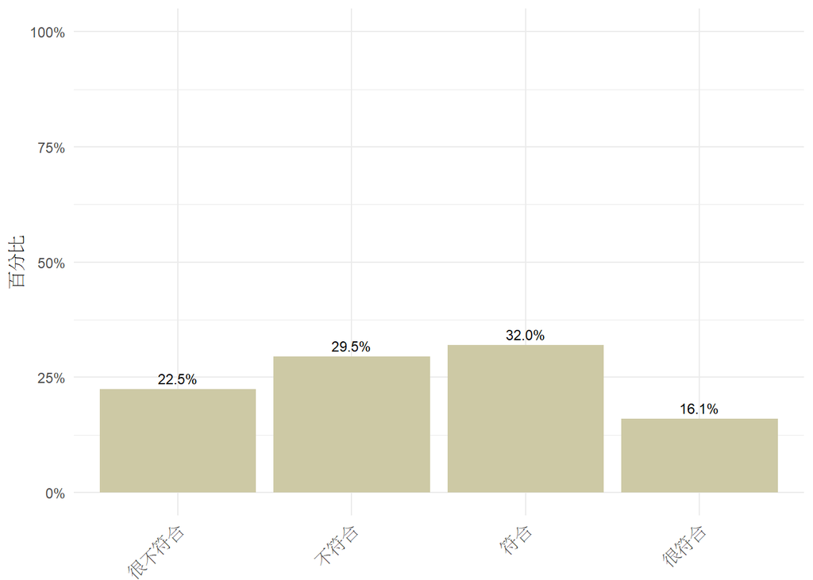

### 親師聯盟_班上同學的群組，不包含導師 (樣本數=561)

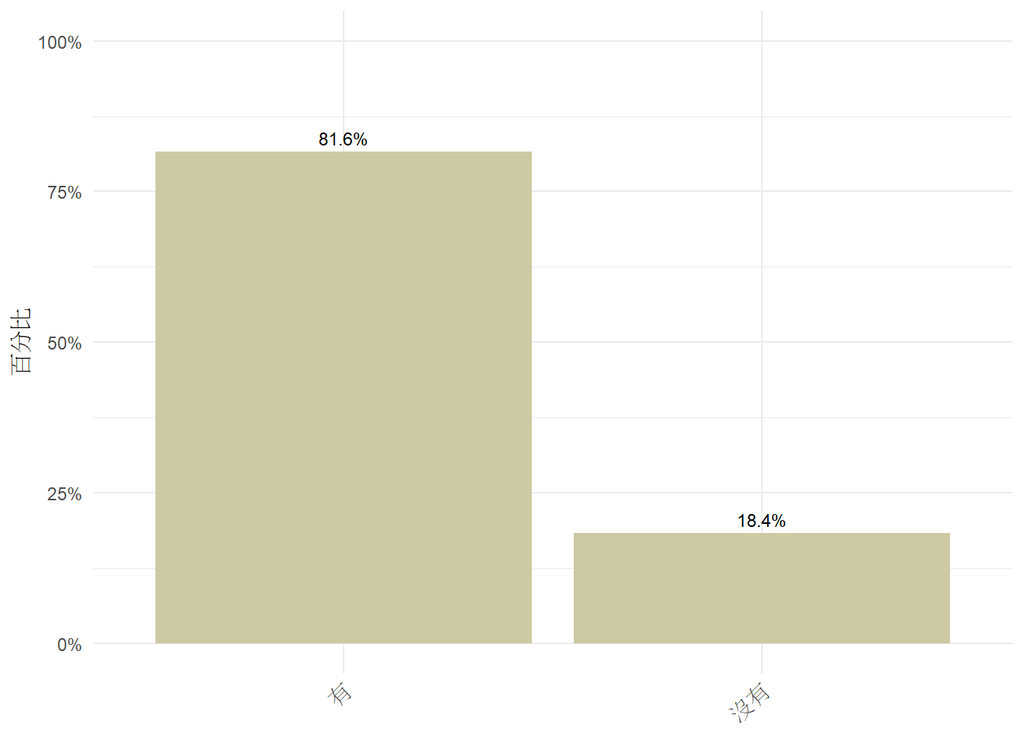

### 親師聯盟_班上同學的群組，導師有加入 (樣本數=559)

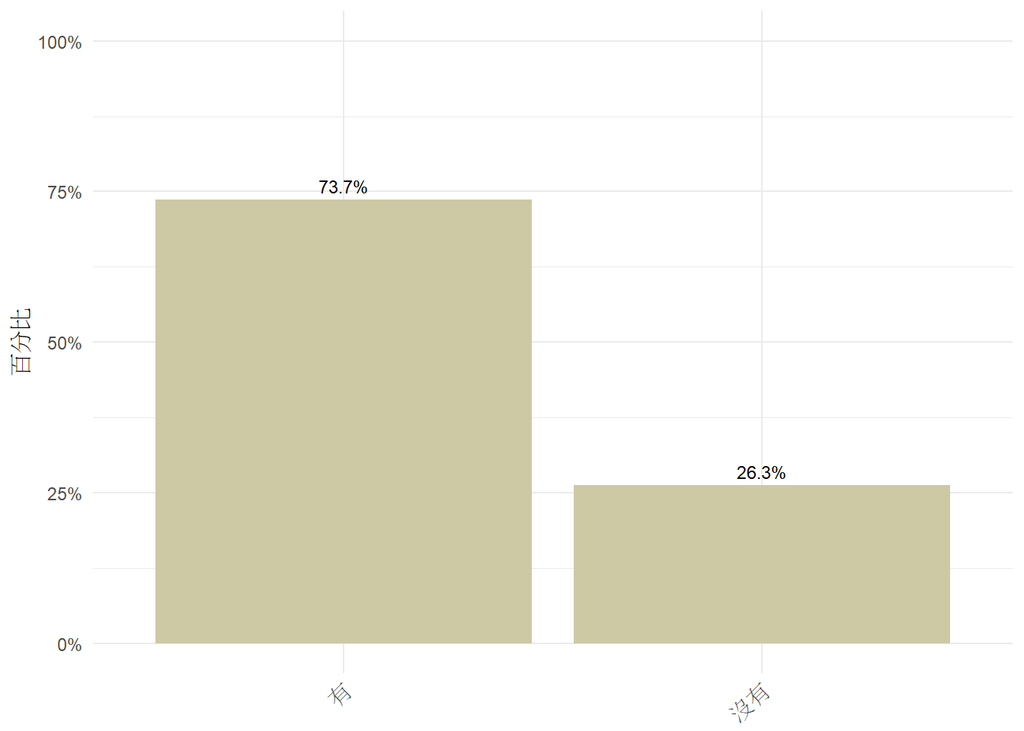

### 親師聯盟_導師是否曾主動聯絡你的家長 (樣本數=501)

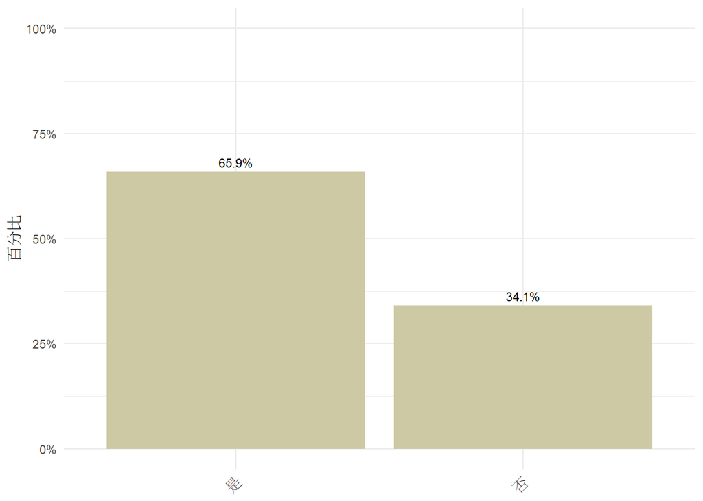

### 親師聯盟_導師多常聯絡你的家長 (樣本數=310)

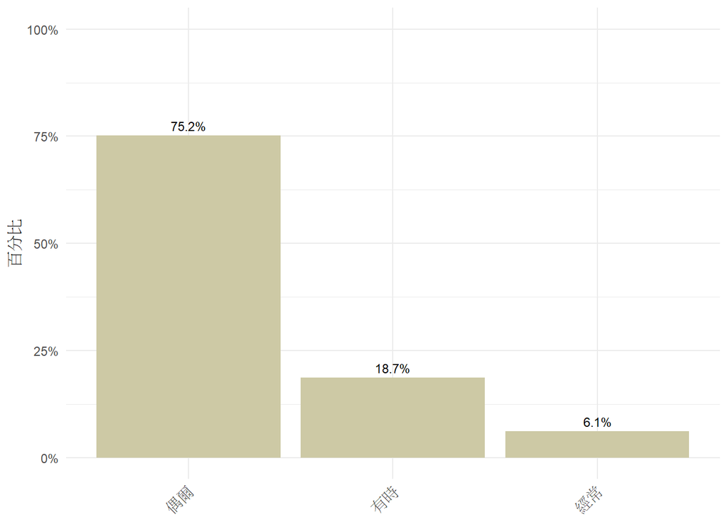

### 親師聯盟_導師通常是連絡哪位家長 (樣本數=326)

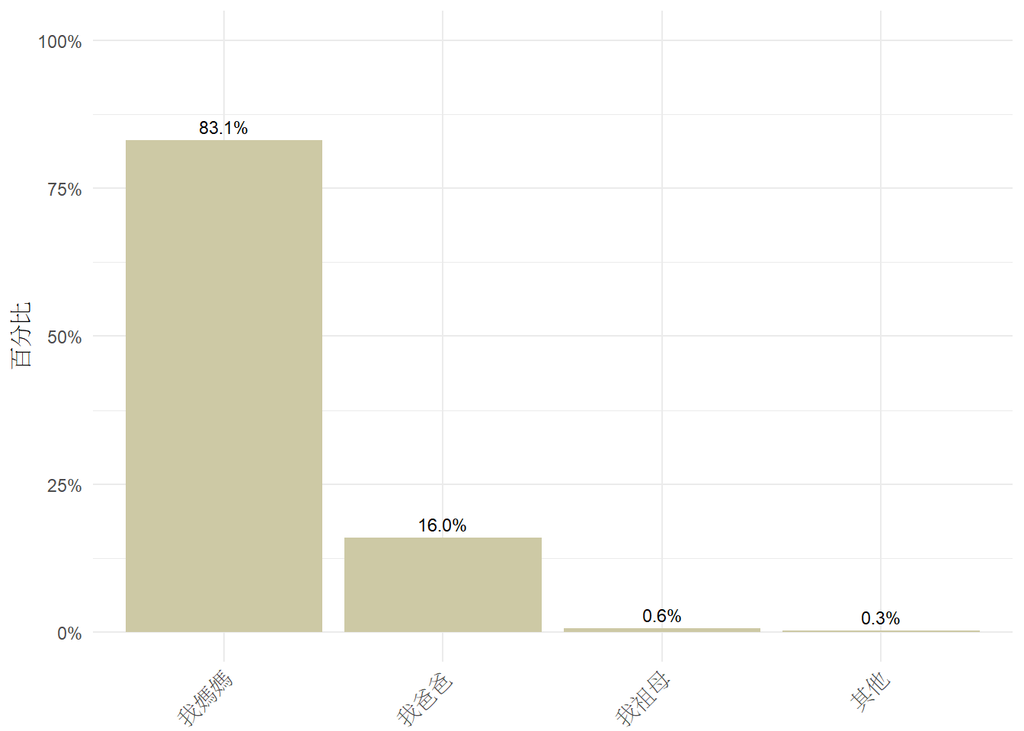

### 親師聯盟_家長是否曾主動聯絡導師 (樣本數=506)

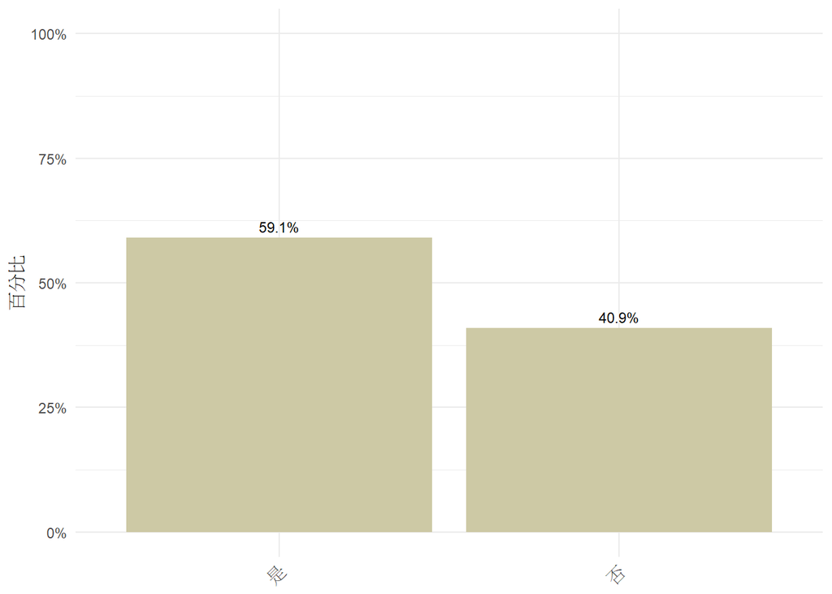

### 親師聯盟_他們多常聯絡你的導師 (樣本數=279)

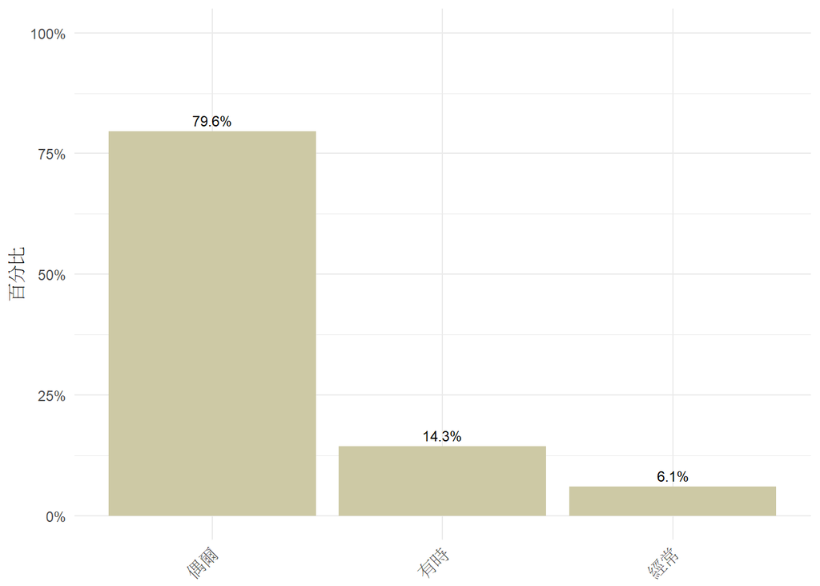

### 親師聯盟_通常是誰連絡你的導師 (樣本數=293)

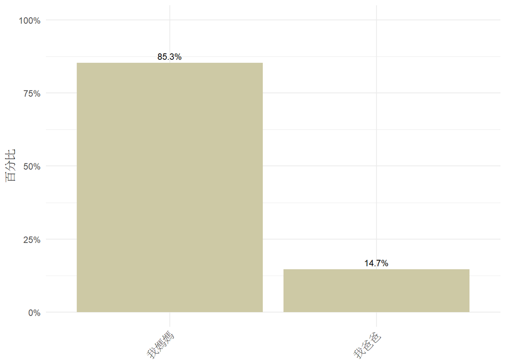

### 親師聯盟_家長是否曾聯絡班上其他家長 (樣本數=490)

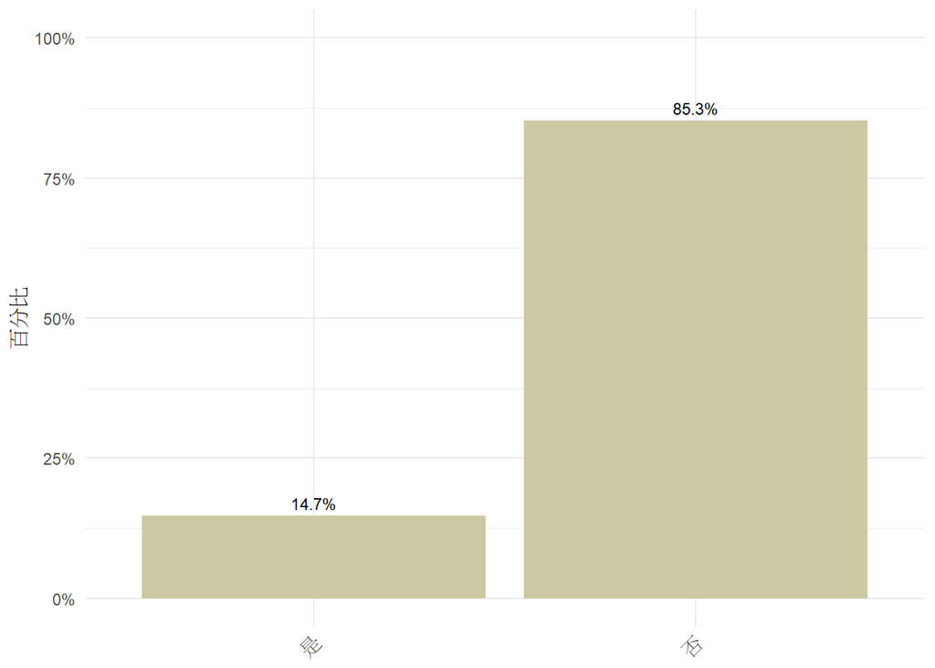

### 親師聯盟_他們多常聯絡其他家長 (樣本數=65)

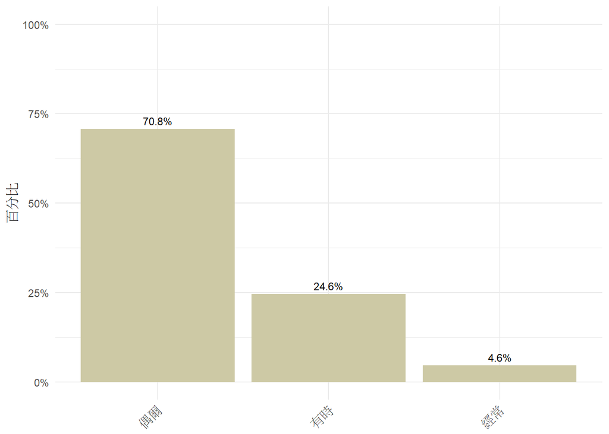

### 親師聯盟_通常是誰連絡其他家長 (樣本數=68)

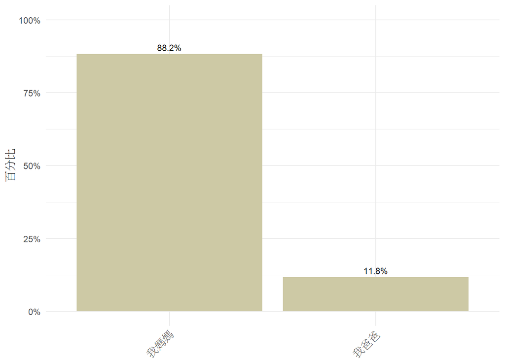

### 霸凌旁觀者_當同學被惡意嘲笑時，我會幫忙被嘲笑的人 (樣本數=604)

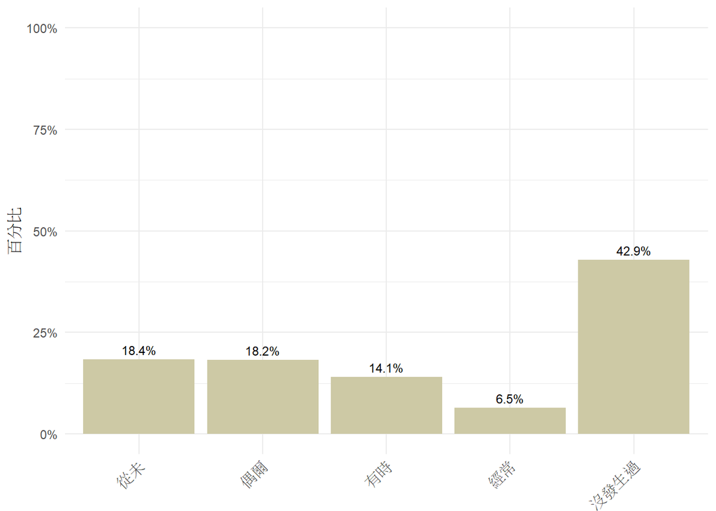

### 霸凌旁觀者_當同學被威脅、騷擾時，我會保護被威脅的人 (樣本數=604)

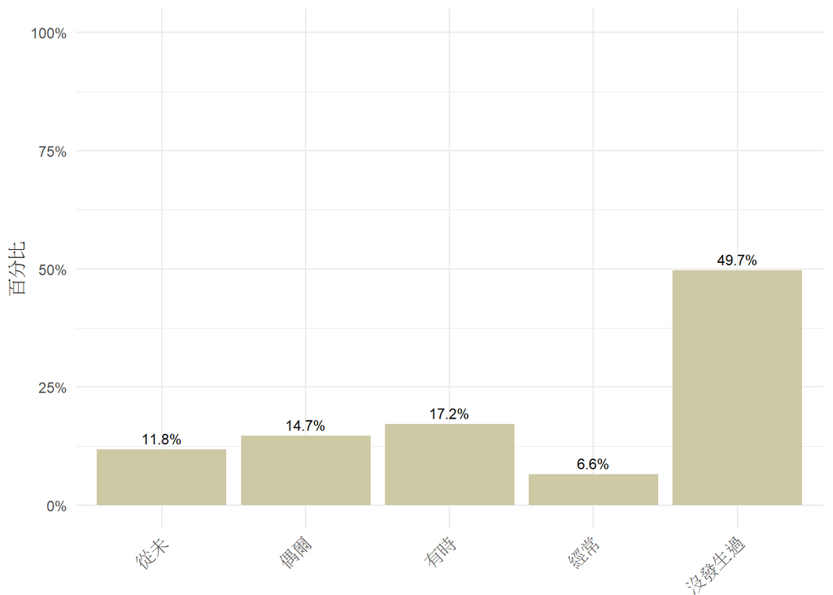

### 霸凌旁觀者_當同學被惡意排擠而無法分組或參加活動時，我會設法讓同學不要被排擠 (樣本數=604)

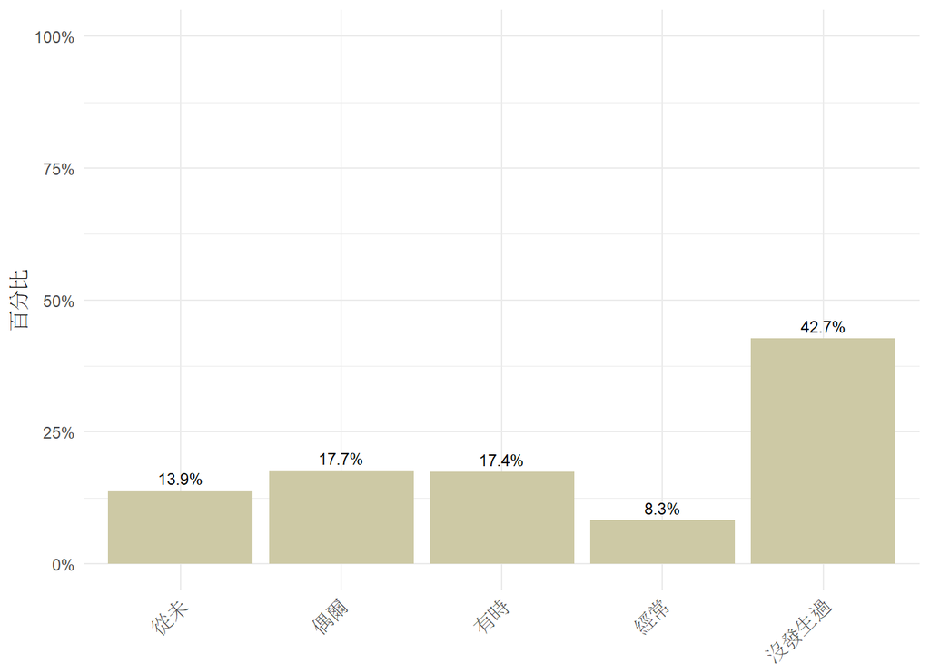

### 霸凌旁觀者_當別人嘲笑特定同學，我不會加入對話，或將這些內容傳給別人 (樣本數=604)

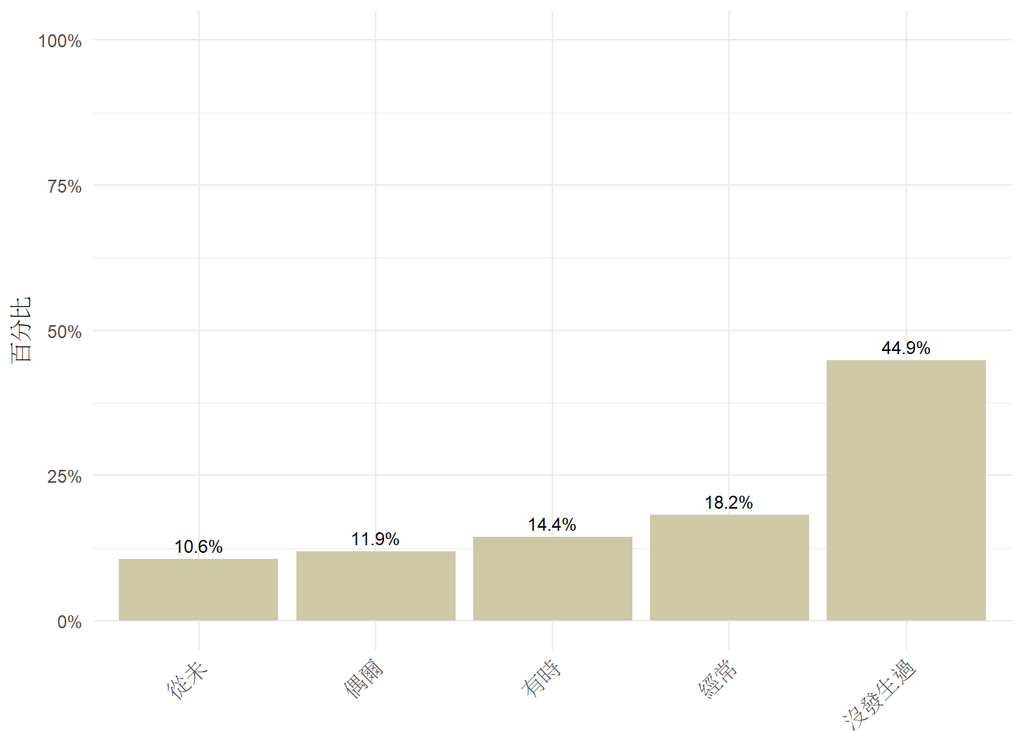

### 霸凌旁觀者_當我知道有同學被威脅、騷擾，我不會有任何反應或行動 (樣本數=604)

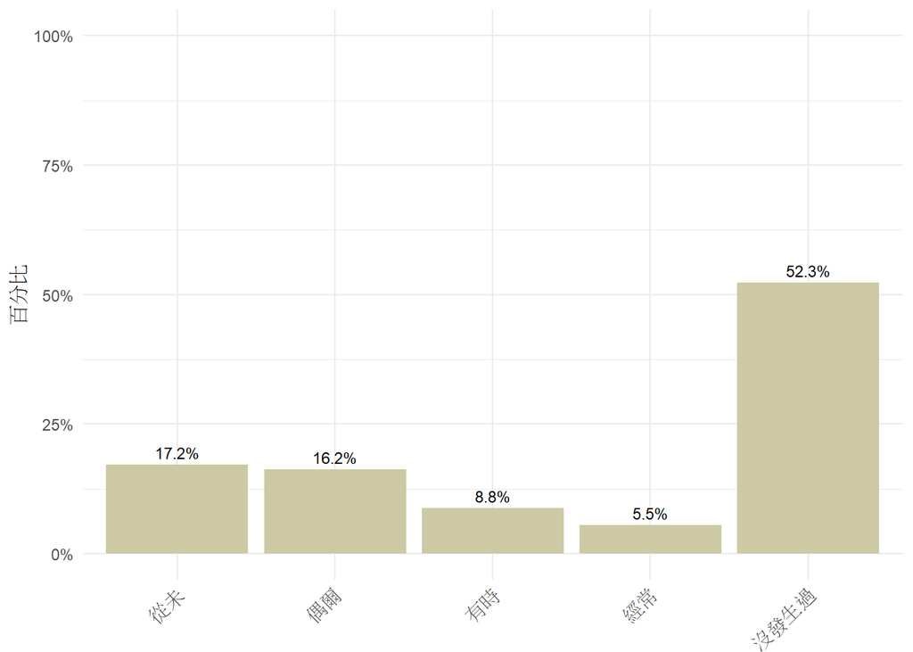

### 霸凌旁觀者_當有人被惡意排擠而無法分組或參加活動時，我不會多管閒事 (樣本數=604)

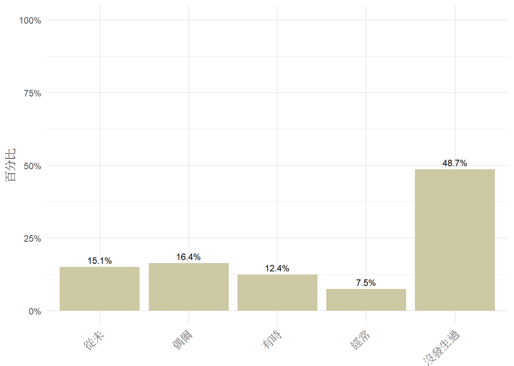

### 霸凌旁觀者_當我收到別人傳來同學的出醜或是不雅照片，我不會傳給別人 (樣本數=604)

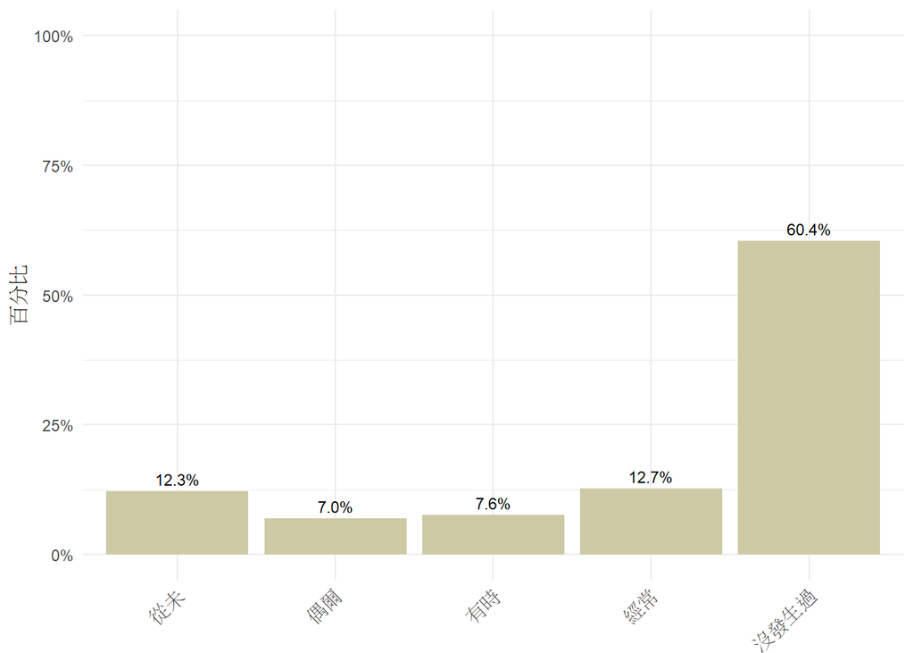

### 霸凌旁觀者_當同學被惡意嘲笑時，我會跟著一起嘲笑那個人 (樣本數=604)

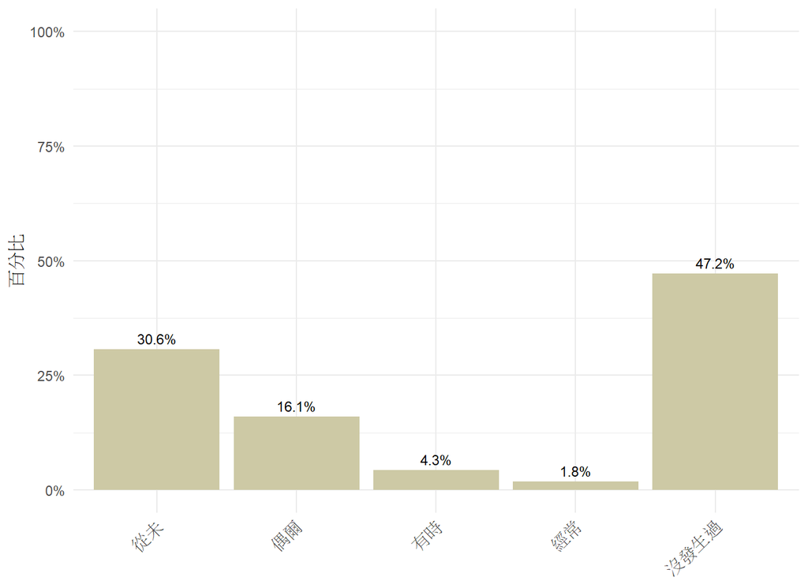

### 霸凌旁觀者_當同學被威脅、騷擾時，我會跟著做這些行為 (樣本數=604)

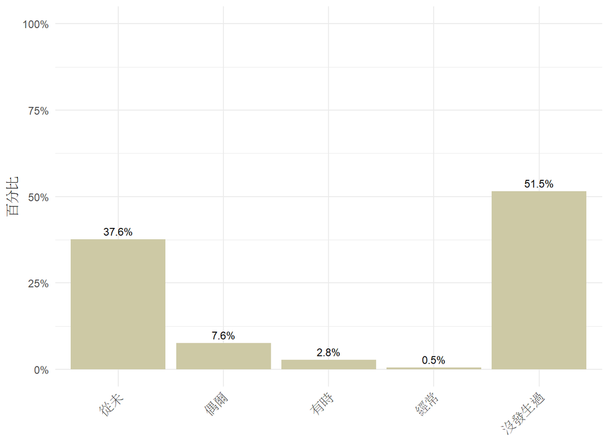

### 霸凌旁觀者_當同學被排擠而無法分組或參加活動時，我也不會跟這個同學一組 (樣本數=603)

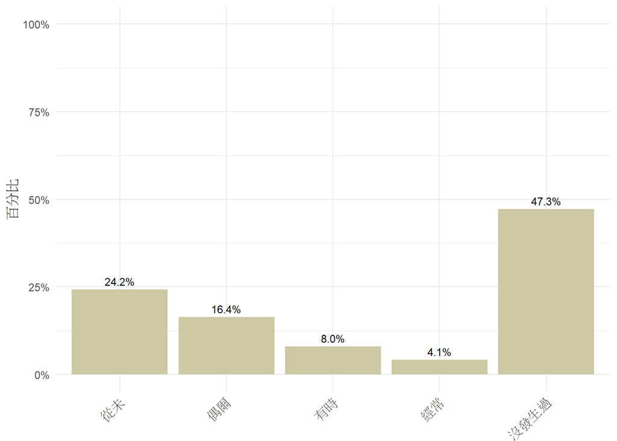

### 霸凌社會規範_我認為霸凌是一種不道德的行為 (樣本數=601)

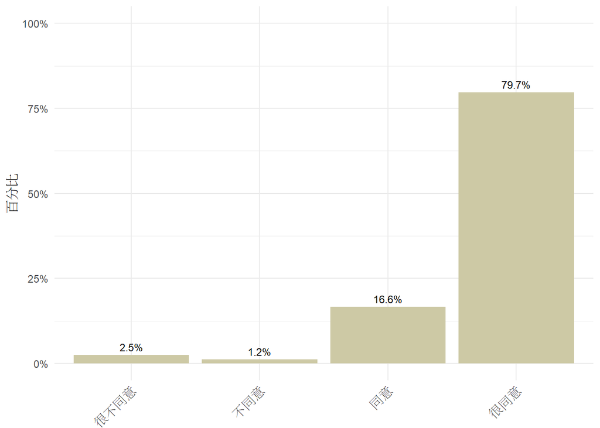

### 霸凌社會規範_我們班很多同學可以容忍霸凌 (樣本數=601)

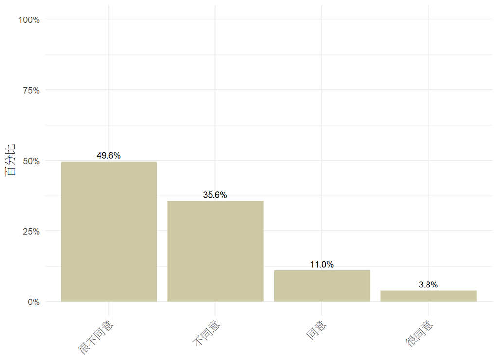

### 現實霸凌受害 (樣本數=599)

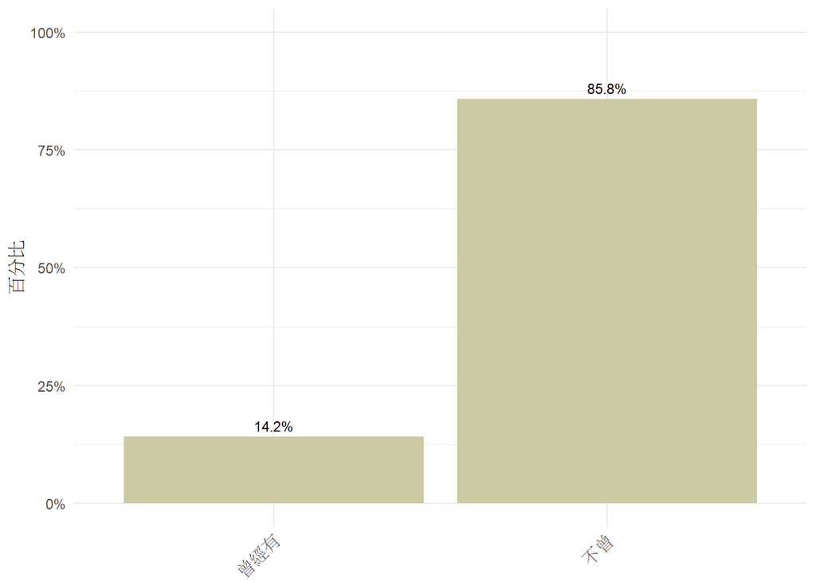

### 現實霸凌受害_別人用髒話罵或威脅我 (樣本數=82)

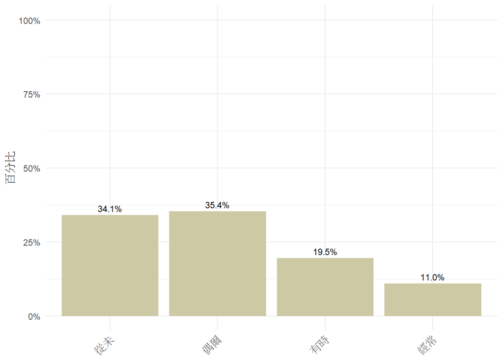

### 現實霸凌受害_別人說我的壞話 (樣本數=82)

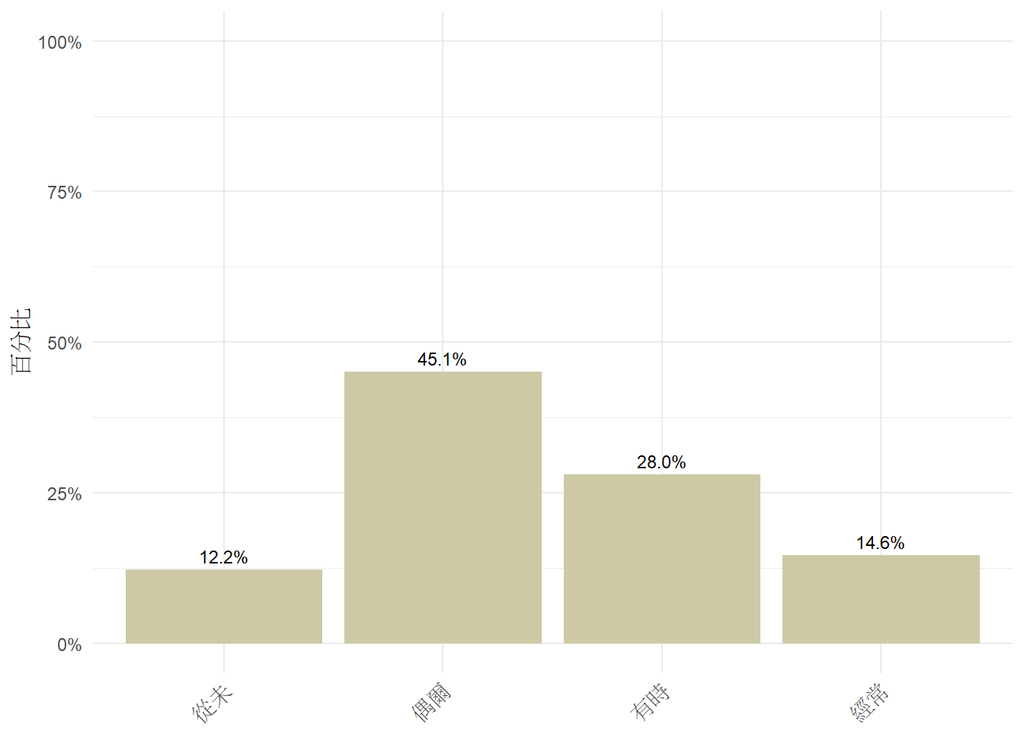

### 現實霸凌受害_不讓我加入討論、活動或不准別人跟我說話、一起行動 (樣本數=82)

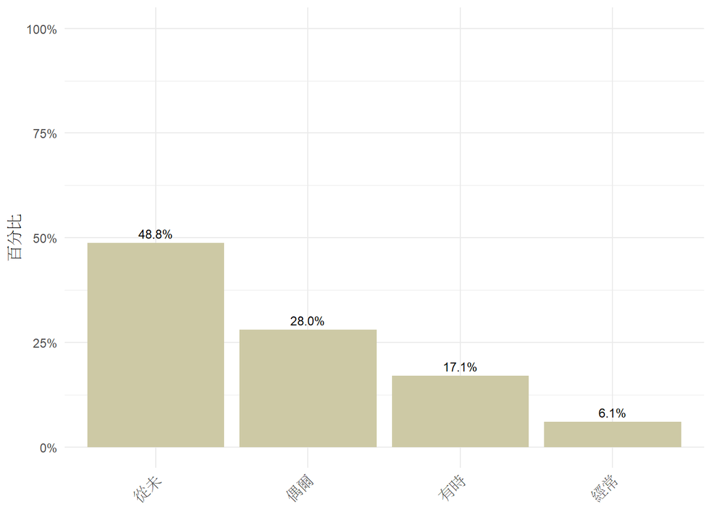

### 現實霸凌受害_被嘲笑外表或言行舉止 (樣本數=82)

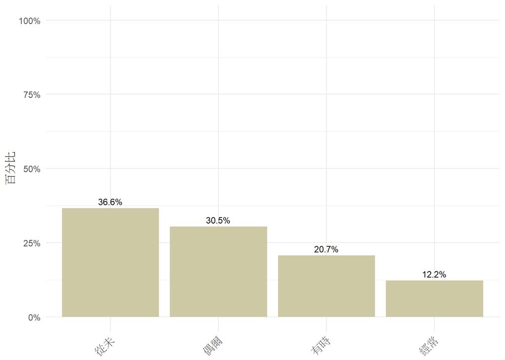

### 現實霸凌受害_被嘲笑我喜歡某個人 (樣本數=82)

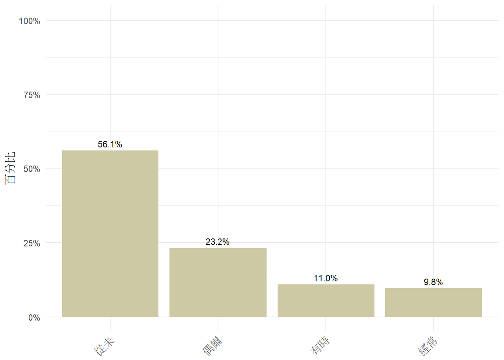

### 現實霸凌受害_故意破壞我的東西或故意藏起來 (樣本數=82)

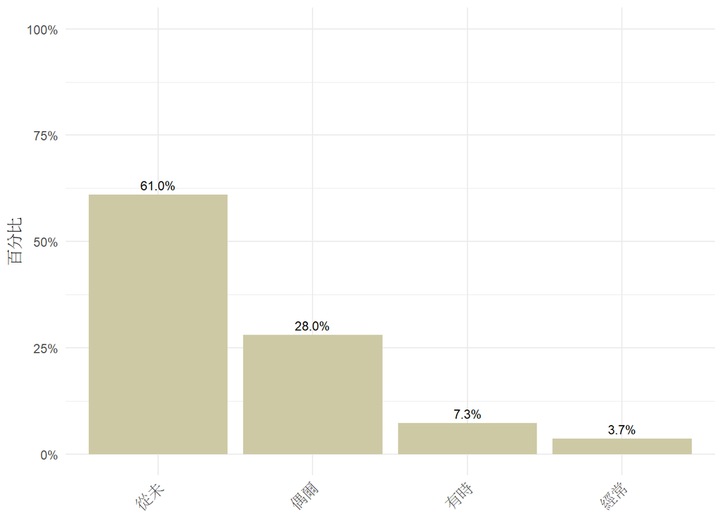

### 現實霸凌受害_勒索或強要我的東西 (樣本數=82)

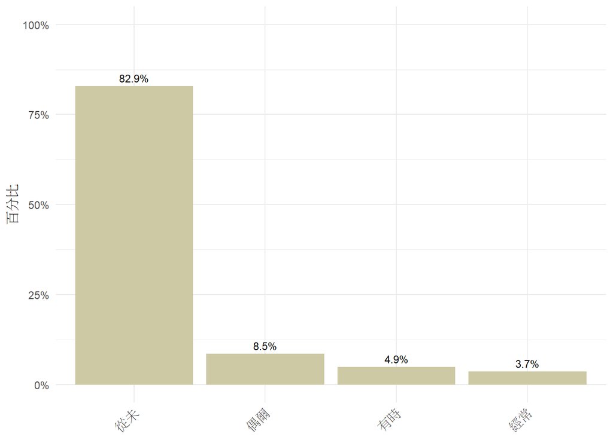

### 現實霸凌受害_別人對我肢體攻擊 (樣本數=82)

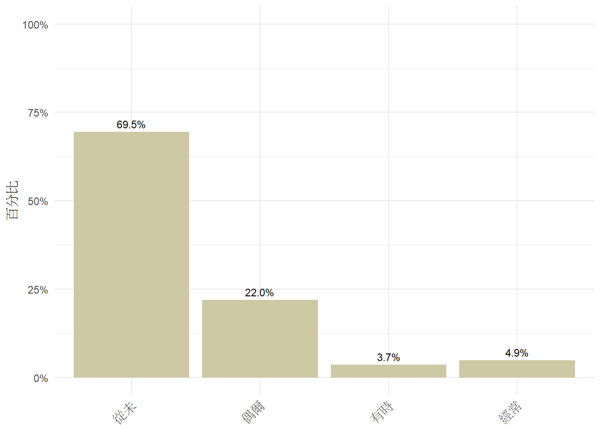

### 現實霸凌受害_對象_同班同學 (樣本數=75)

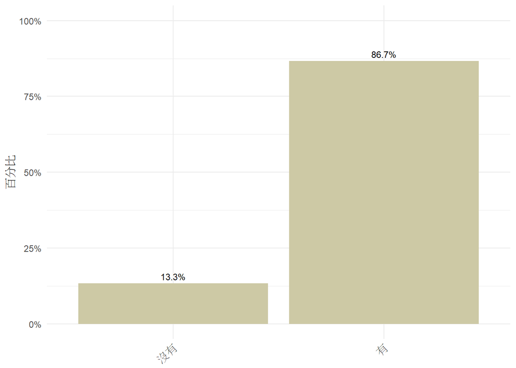

### 現實霸凌受害_對象_同校不同班的同學 (樣本數=75)

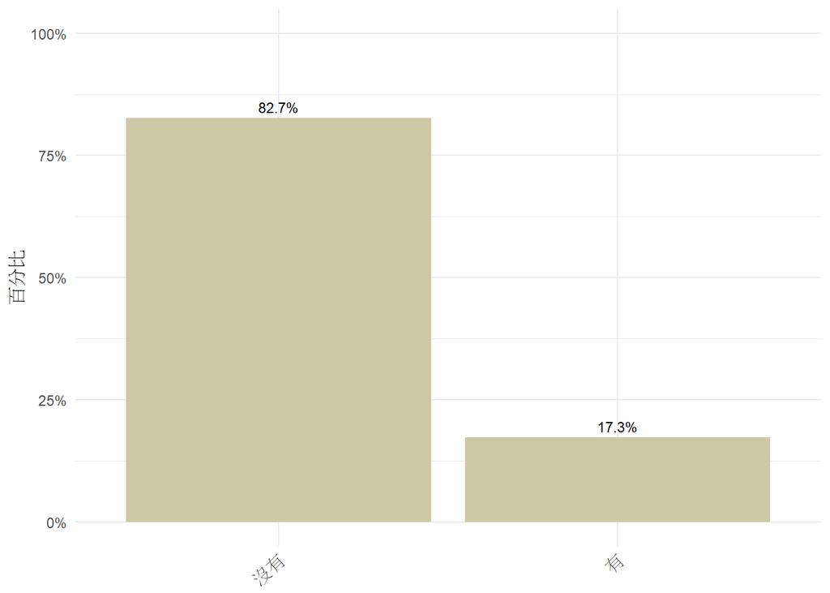

### 現實霸凌受害_對象_不同校的朋友 (樣本數=75)

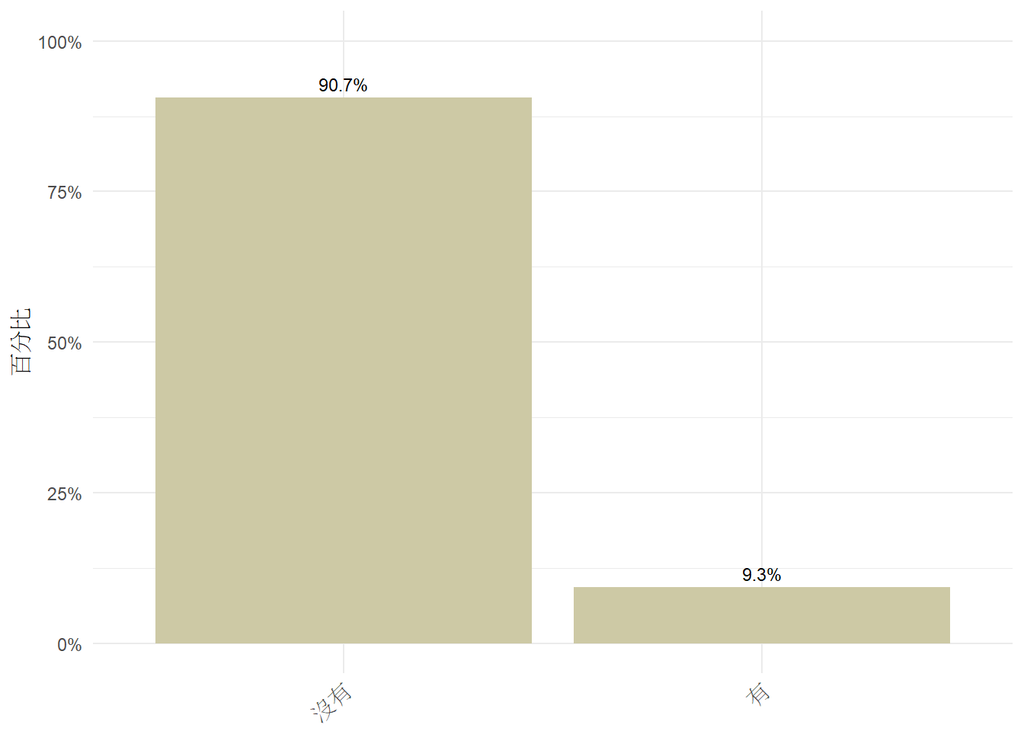

### 現實霸凌受害_對象_其他 (樣本數=75)

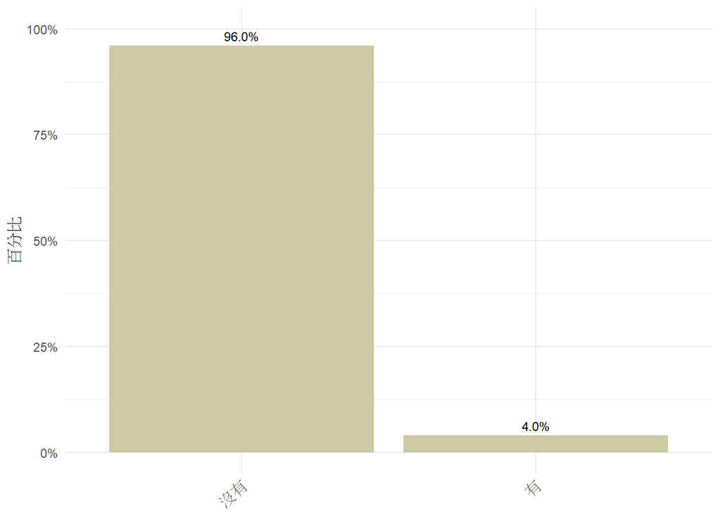

### 現實霸凌受害_反應_好好說明澄清 (樣本數=77)

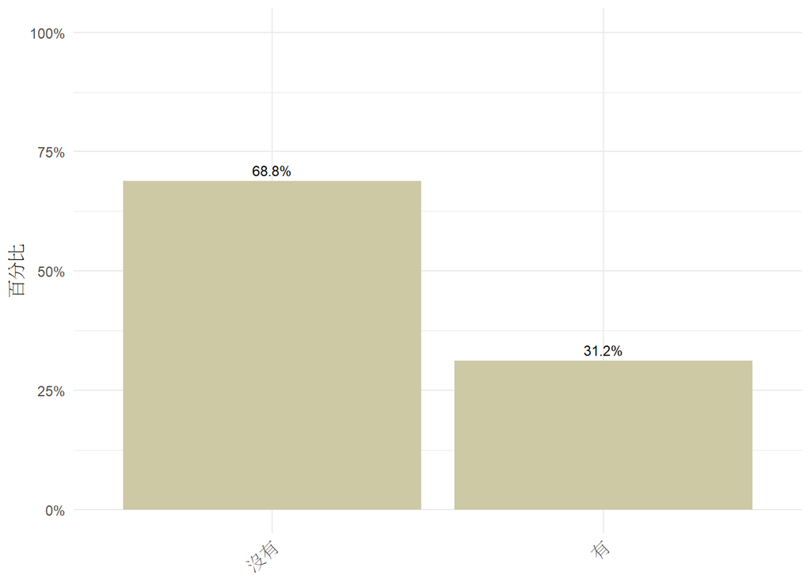

### 現實霸凌受害_反應_要求當事人停止 (樣本數=77)

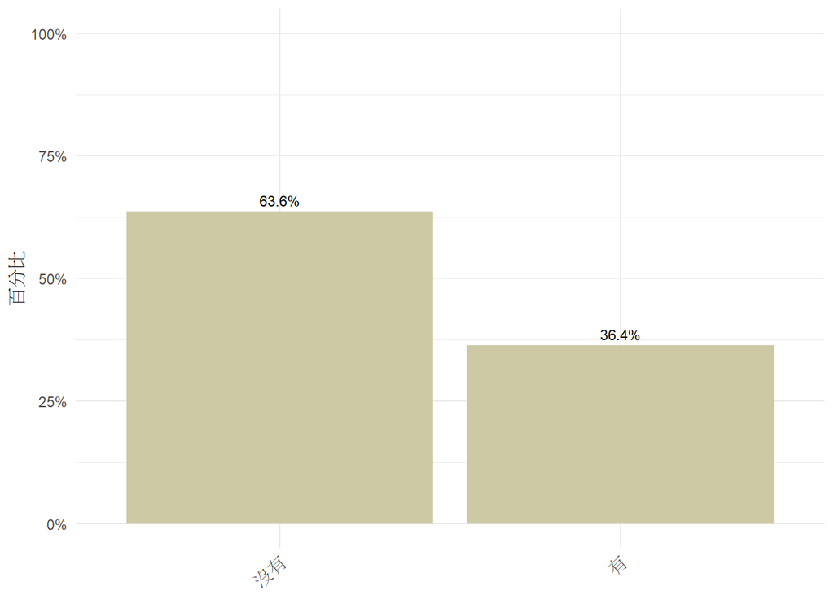

### 現實霸凌受害_反應_忽略這些人與事情 (樣本數=77)

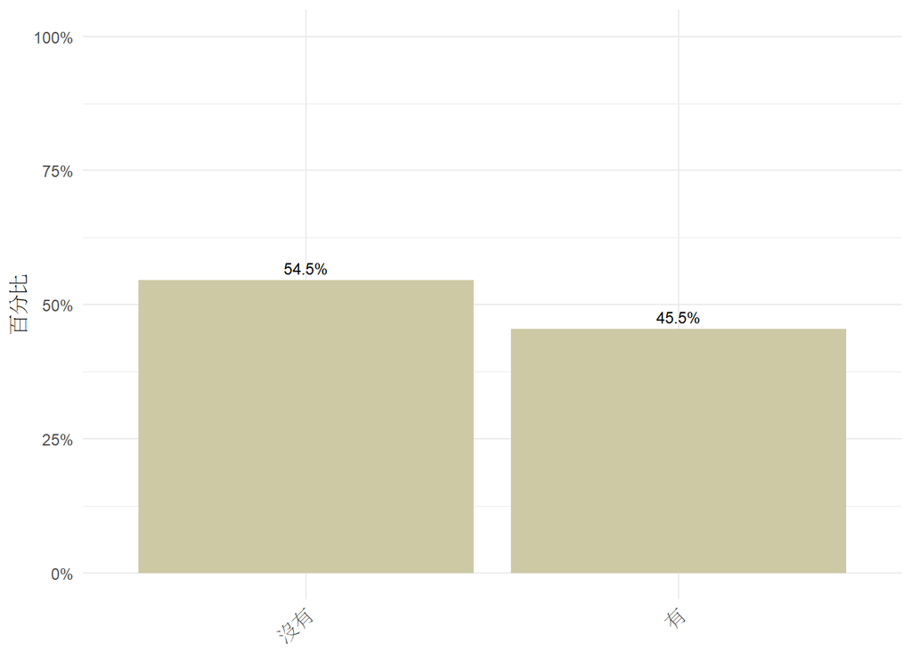

### 現實霸凌受害_反應_投入其他有趣或有意義的事情 (樣本數=77)

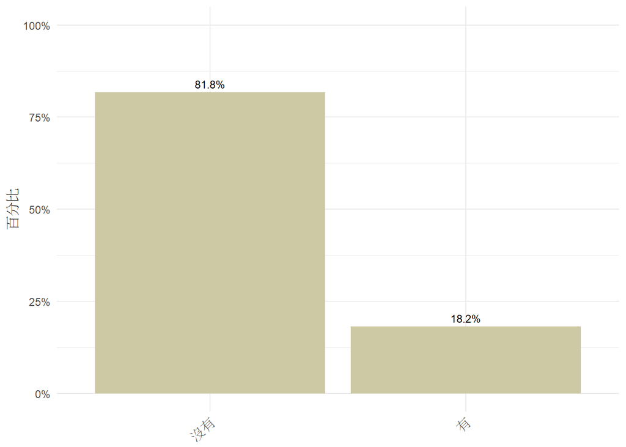

### 現實霸凌受害_反應_因為太困擾，無法做好平日應該要做的事 (樣本數=77)

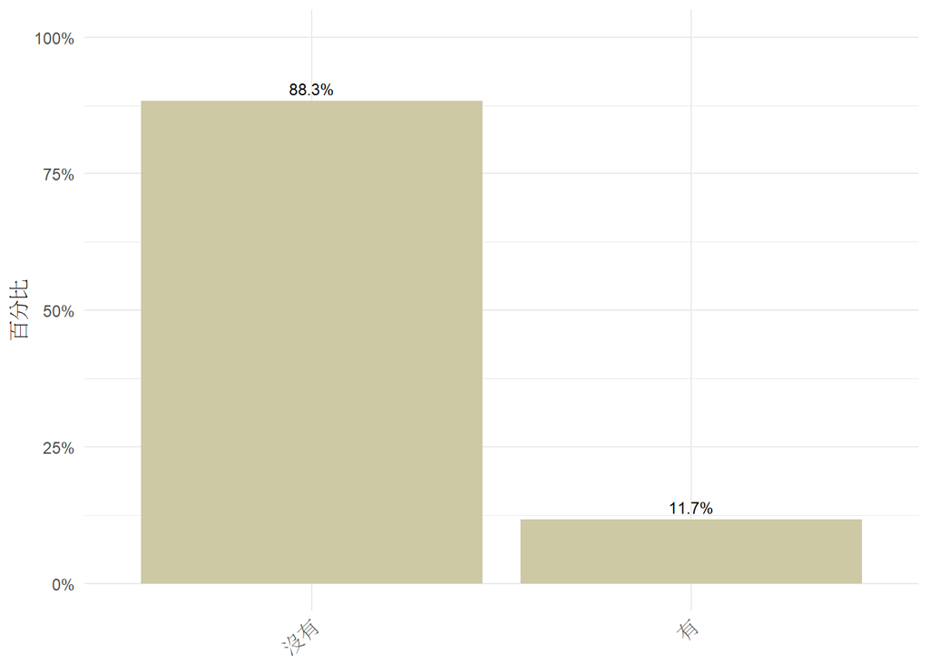

### 現實霸凌受害_反應_回擊、跟當事人對抗 (樣本數=77)

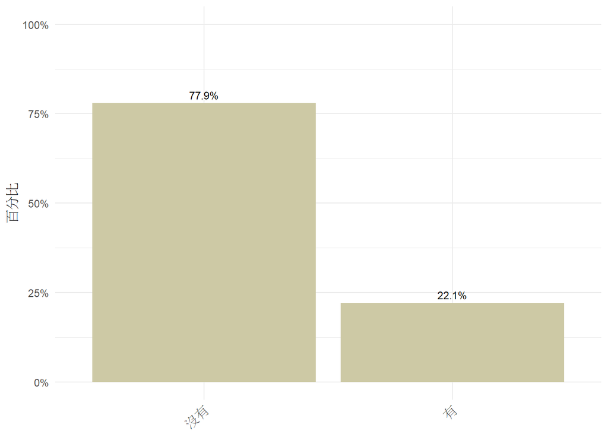

### 現實霸凌受害_反應_告訴其他同學或朋友 (樣本數=77)

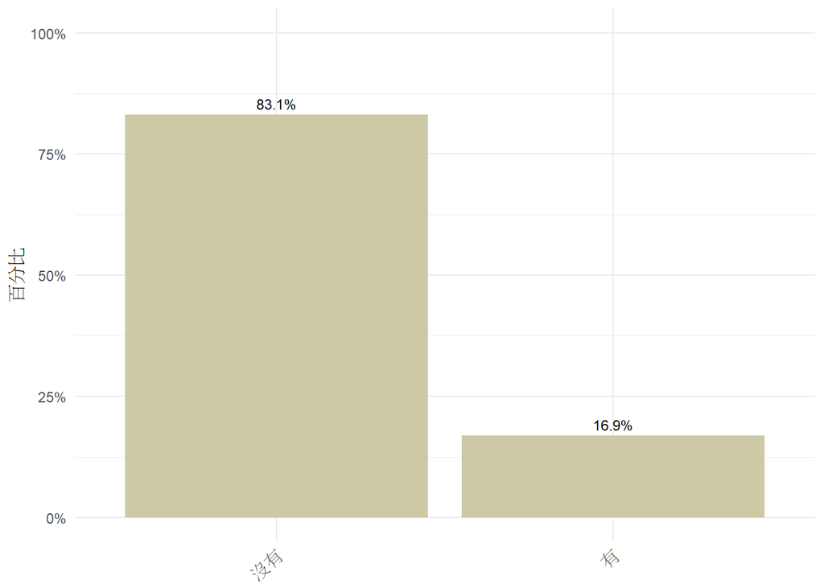

### 現實霸凌受害_反應_告訴家人 (樣本數=77)

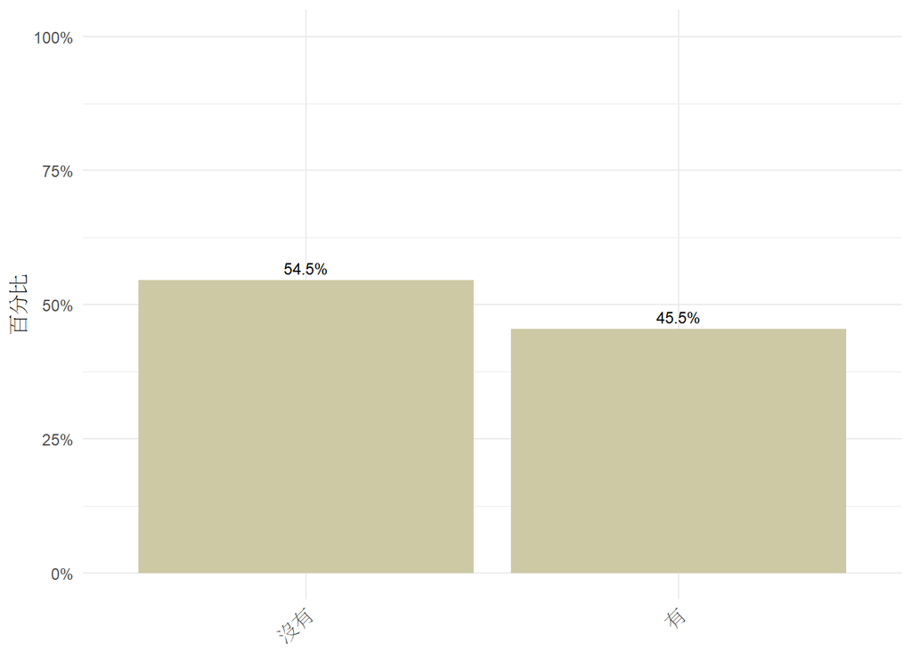